# Homework 3

Matthew Smith

10/25/2018

# 1. CASL Page 117, Question 7

In this problem, we create a density function using the Epanechnikov Kernel. For $x \in \mathbb{R}$, the Epanechnikov Kernel is defined as
$$K(x) = \frac{3}{4}(1-x^2)\unicode{x1D7D9}_{\{\lvert x \rvert \leq 1\}}.$$
We can easily see that this is non-negative, symmetric about the origin, and integrates to $1$, all of the properties we want for a kernel. We generalize this kernel by giving it a bandwidth of $h > 0$:
$$\begin{array}{rcll}
K_h(x) & = & \frac{1}{h}K(\frac{x}{h})\\
& = & \frac{3}{4h}\Big(1-(\frac{x}{h})^2\Big)\unicode{x1D7D9}_{\{\lvert \frac{x}{h} \rvert \leq 1\}}.\\
\end{array}$$
I have written a function `epan_kernel` in the `epan-kernel.R` file contained within this package that calculates exactly this scaled Epanechnikov Kernel:

```r
library(bis557)
epan_kernel
```

```
## function(x, h=1){
##   x_scaled <- x/h #Make a vector of the scaled values of x
##   indic <- as.numeric(abs(x_scaled) <= 1) #This is the indicator to see if the scaled values of x are in the required range
##   # as.numeric makes TRUE into 1 and FALSE into 0
##   (3/4) * (1 - x_scaled^2) * indic / h #Plug every value of x_scaled into the function, but then multiply every value by the indicator
##   # Return this value
## }
## <environment: namespace:bis557>
```

Now that we have our function for the kernel, we can use that kernel to create a density estimator. Given any kernel $K_h(x)$, we can construct a density estimate $f_h(x)$ from it as
$$f_h(x) = \frac{1}{n}\sum_{i=1}^n K_h(x-x_i)$$
using $n$ training points $x_i$ in $\mathbb{R}$. The factor of $\frac{1}{n}$ ensures that this function, like any good density estimator, will integrate over $\mathbb{R}$ to $1$. Also in the `epan-kernel.R` file in this package, I have written a function `kern_density` that does exactly this, using training data `x`, bandwidth `h`, and a vector of test data `x_new`:

```r
kern_density
```

```
## function(x, h, x_new){
##   vapply(x_new, function(w){ #We use the vapply funcion to vectorize the function, which then returns a vector
##     # We vectorize this anonymous function that actually does what we want
##     mean(vapply(x, function(u){ #Now we vectorize over all the values of the test data x
##       epan_kernel(w-u, h) #We use w for the current value of x_new and u for the current value of x
##     }, FUN.VALUE=as.numeric(NA))) #For each value w in x_new, we take the arithmetic mean of all these Epanechnikov Kernels
##   }, FUN.VALUE=as.numeric(NA)) #We use FUN.VALUE to specify the default value type (numeric here)
## }
## <environment: namespace:bis557>
```

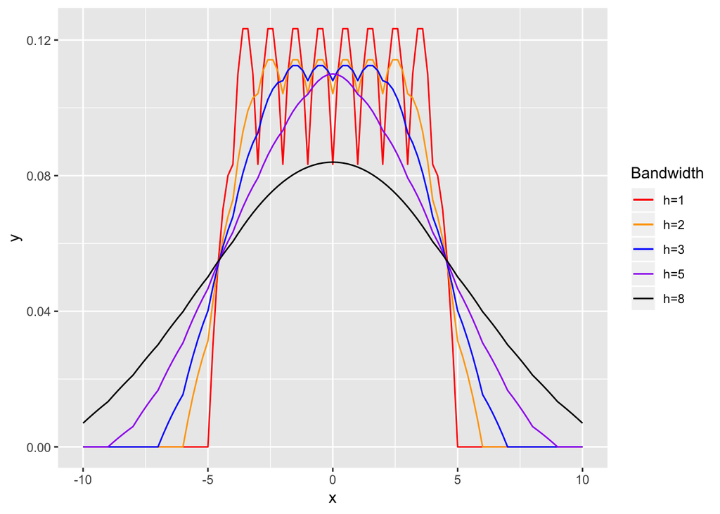

```r
library(ggplot2)
x_data <- -4:4 #The data vector
ggplot(data.frame(x=0), aes(x=x)) + stat_function(fun=function(x){kern_density(x_data, 1, x)}, aes(color="h=1")) + stat_function(fun=function(x){kern_density(x_data, 2, x)}, aes(color="h=2")) + stat_function(fun=function(x){kern_density(x_data, 3, x)}, aes(color="h=3")) + stat_function(fun=function(x){kern_density(x_data, 5, x)}, aes(color="h=5")) + stat_function(fun=function(x){kern_density(x_data, 8, x)}, aes(color="h=8")) + scale_color_manual("Bandwidth", values=c("red", "orange", "blue", "purple", "black")) + xlim(-10,10)
```

We can see that this density estimator flattens out as the bandwidth $h$ increases, since we are including more points for which to average the kernel.

# 2. CASL Page 200, Question 3

By the Definition in Section 7.4 (Equation 7.25), a function $f:\mathbb{R}^p\to\mathbb{R}$ is *convex* if $\forall b_1, b_2 \in \mathbb{R}^p$ and $\forall t \in [0,1]$, we have
$$f(tb_1 + (1-t)b_2) \leq tf(b_1) + (1-t)f(b_2).$$
If $f,g:\mathbb{R}^p\to\mathbb{R}$ are both convex, and $h = f + g$, then $\forall b_1, b_2 \in \mathbb{R}^p$ and $\forall t \in [0,1]$,
$$\begin{array}{rcll}
h(tb_1 + (1-t)b_2) & = & (f+g)(tb_1 + (1-t)b_2)\\
& = & f(tb_1 + (1-t)b_2) + g(tb_1 + (1-t)b_2)\\
& \leq & tf(b_1) + (1-t)f(b_2) + g(tb_1 + (1-t)b_2)\\
& \leq & tf(b_1) + (1-t)f(b_2) + tg(b_1) + (1-t)g(b_2)\\
& = & tf(b_1) + tg(b_1) + (1-t)f(b_2) + (1-t)g(b_2)\\
& = & t(f+g)(b_1) + (1-t)(f+g)(b_2)\\
& = & th(b_1) + (1-t)h(b_2).\\
\end{array}$$
Thus $h(tb_1 + (1-t)b_2) \leq th(b_1) + (1-t)h(b_2)$ $\forall b_1, b_2 \in \mathbb{R}^p$ and $\forall t \in [0,1]$. So, if $f$ and $g$ are both convex functions, then their sum $h=f+g$ is as well.

# 3. CASL Page 200, Question 4

First we will show that the absolute value function is convex. We will use the above definition for convex functions. Since $t\in[0,1]$, $t$ and $1-t$ are both non-negative. This means, $\forall x \in \mathbb{R}$, $\lvert tx \rvert = t \lvert x \rvert$ and $\lvert (1-t)x \rvert = (1-t) \lvert x \rvert$. The absolute value function also follows the *Triangle Inequality*: $\forall x,y \in \mathbb{R}$, $\lvert x+y \rvert \leq \lvert x \rvert + \lvert y \rvert$. Then, $\forall x,y \in \mathbb{R}$ and $\forall t \in [0,1]$,
$$\begin{array}{rcll}
\lvert tx + (1-t)y \rvert & \leq & \lvert tx \rvert + \lvert (1-ty) \vert\\
& = & t \lvert x \rvert + (1-t) \lvert y \rvert.\\
\end{array}$$
By definition, this means that the absolute value function is convex.

In the previous question, we showed that the sum of two convex functions is also convex. Using induction, we can show that *any* finite sum of $p$ convex functions is also convex. The above proof would work both as the base case and the induction step.

The $\ell_1$-norm is defined as $\lvert\lvert \vec{x} \rvert\rvert_1 = \sum_{i=1}^p \lvert x_i \rvert$, $\forall x \in \mathbb{R}^p$. We can consider each $\lvert x_i \rvert$ as a function from $\mathbb{R}^p$ to $\mathbb{R}$ that takes a vector in $\mathbb{R}^p$ and returns the absolue value of the $i$th element. We need to do this because the normal, familiar absolute value function is only a function from $\mathbb{R}$ to $\mathbb{R}$, but our $\ell_1$-norm is a function from $\mathbb{R}^p$ to $\mathbb{R}$. Since each $\lvert x_i \rvert$ is a convex function, the sum of all these convex absolute value functions is also convex. Then, the $\ell_1$-norm is convex.

# 4. CASL Page 200, Question 5

The Elastic Net objective function (the one that we optimize to find $\hat{\beta}^{\ell_1}$) is defined as
$$f(b) = \frac{1}{2n} \lvert\lvert y - Xb \rvert\rvert_2^2 + \lambda\Big((1-\alpha)\lvert\lvert b \rvert\rvert_2^2 + \alpha\lvert\lvert b \rvert\rvert_1\Big),$$
where $\lambda > 0$, $\alpha \in [0,1]$, $y \in \mathbb{R}^n$, $X \in \textrm{M}_{n \times p}(\mathbb{R})$, and $b \in \mathbb{R}^p$. We already showed above that the sum of convex functions is convex and that the $\ell_1$-norm is convex, so all we need to do to show that $f(b)$ is convex is prove that the $\ell_2$-norm sauared is convex and that any constant multiple of a convex function is also convex.

On this first fron, we note that the $\ell_2$-norm squared can be defined, for a vector $x$ in $\mathbb{R}^n$ (or $\mathbb{R}^p$) as
$$\lvert\lvert x \rvert\rvert_2^2 \triangleq \sum_{i=1}^n\lvert x_i \rvert^2.$$
Since we are only looking at $\mathbb{R}^n$ and not $\mathbb{C}^n$, we do not need to worry about the absolute values in the squared components:
$$\lvert\lvert x \rvert\rvert_2^2 = \sum_{i=1}^n x_i^2.$$
This simplification allows us just to look at the square function. We already showed that the sum of convex functions is also convex, so if we can show that each individual square function in $\mathbb{R}$ is convex, then their sum will be as well, and so will the $\ell_2$-norm squared.

To check the convexity of the square function, we will use the second derivative test. That is, for a function $g:\mathbb{R}\to\mathbb{R}$, $g$ is convex wherever $\frac{\textrm{d}^2g}{\textrm{d}x^2} > 0$. Luckily for us, if $g(x) = x^2$, then $\frac{\textrm{d}^2g}{\textrm{d}x^2} = 2 > 0$ everywhere in $\mathbb{R}$, so the square function $g(x) = x^2$ is convex everywhere in $\mathbb{R}$.

Now we can consider each $x_i^2$ to really be a function from $\mathbb{R}^n$ to $\mathbb{R}$, where we only return the square of the $i$th element from the vector $x$. This function is still a convex function, but now we have the same domain and codomain as the $\ell_2$-norm squared. Using what we determined previously about the sum of convex functions, we know that the $\ell_2$-norm squared, which is the sum of these convex square functions from $\mathbb{R}^n$ to $\mathbb{R}$, is also convex. It is convex both from $\mathbb{R}^n$ to $\mathbb{R}$ and from $\mathbb{R}^p$ to $\mathbb{R}$.

Lastly, we need to check that a constant multiple of a convex function is also convex, which is pretty straightforward. If $g:\mathbb{R}^p\to\mathbb{R}$ is convex, $a$ is a constant in $\mathbb{R}$, and $h = ag$, then we can easily show $h$ is convex: $\forall b_1, b_2 \in \mathbb{R}^p$ and $\forall t \in [0,1]$, we have
$$\begin{array}{rcll}
h(tb_1 + (1-t)b_2) & = & ag(tb_1 + (1-t)b_2)\\
& \leq & a(tg(b_1) + (1-t)g(b_2))\\
& = & atg(b_1) + a(1-t)g(b_2)\\
& = & tag(b_1) + (1-t)ag(b_2)\\
& = & th(b_1) + (1-t)h(b_2).\\
\end{array}$$
Thus, $h(tb_1 + (1-t)b_2) \leq th(b_1) + (1-t)h(b_2)$, so $h = ag$ is convex if $g$ is convex.

Putting this all together, we see that the Elastic Net objective function $f(b) = \frac{1}{2n} \lvert\lvert y - Xb \rvert\rvert_2^2 + \lambda\Big((1-\alpha)\lvert\lvert b \rvert\rvert_2^2 + \alpha\lvert\lvert b \rvert\rvert_1\Big)$ is convex, because it is made up of sums and constant multiples of the $\ell_1$-norm and $\ell_2$-norm squared functions, all of which are convex, leading to the larger function being convex.

# 5. CASL Page 200, Question 6

In this problem, we make a function that tests which elements of a LASSO linear regression coefficient vector break the Karush-Kuhn-Tucker (KKT) Conditions. We will simplify the function by assuming that the ridge regression coefficient $\alpha$ is $1$, so we have purely LASSO in our elastic net and no ridge regression.

We create a function `break_kkt` that takes a standardized (mean $0$ and variance $1$ for each column) data matrix `X_stand`, a response vector `y`, a coefficient vector `b` to test, and a value for `lambda`. We make it in the `break-kkt.r` file and will re-print it here.

```r
break_kkt
```

```
## function(b, X, y, lambda){
##   if(length(b) != ncol(X) | length(y) != nrow(X)){ #First check to make sure the dimensions of everything agree
##     print("Error: incorrect number of dimensions somewhere.")
##   }else{
##     ret <- rep(FALSE, length(b)) #Initialize the return object to be a vector of FALSE
##     for(j in 1:length(ret)){ #For each coefficient
##       test_var <- sum(X[,j] * (y - X %*% b)) /nrow(X) #Using EQ 7.37 on page 188, using element-wise multiplication before we sum over the rows
##       s <- round(test_var / lambda) #This is the s-value in the equation to test the KKT Conditions
##       # We unfortunately have to round this to the nearest integer because glmnet does not produce very accurate coefficients,
##       # even when we provide it a vector of lambda values
##       if(b[j] > 0){
##         ret[j] <- !(s == 1) #We are testing to see if the KKT Conditions are BROKEN, not satisfied
##       }else if(b[j] == 0){
##         ret[j] <- !(-1 <= s & s <= 1)
##       }else{ #If negative
##         ret[j] <- !(s == -1)
##       }
##     }
##     ret #Returning the logical vector
##   }
## }
## <environment: namespace:bis557>
```

We test this function using the example from the `iris` data set included in the documentation for `kkt_break`.

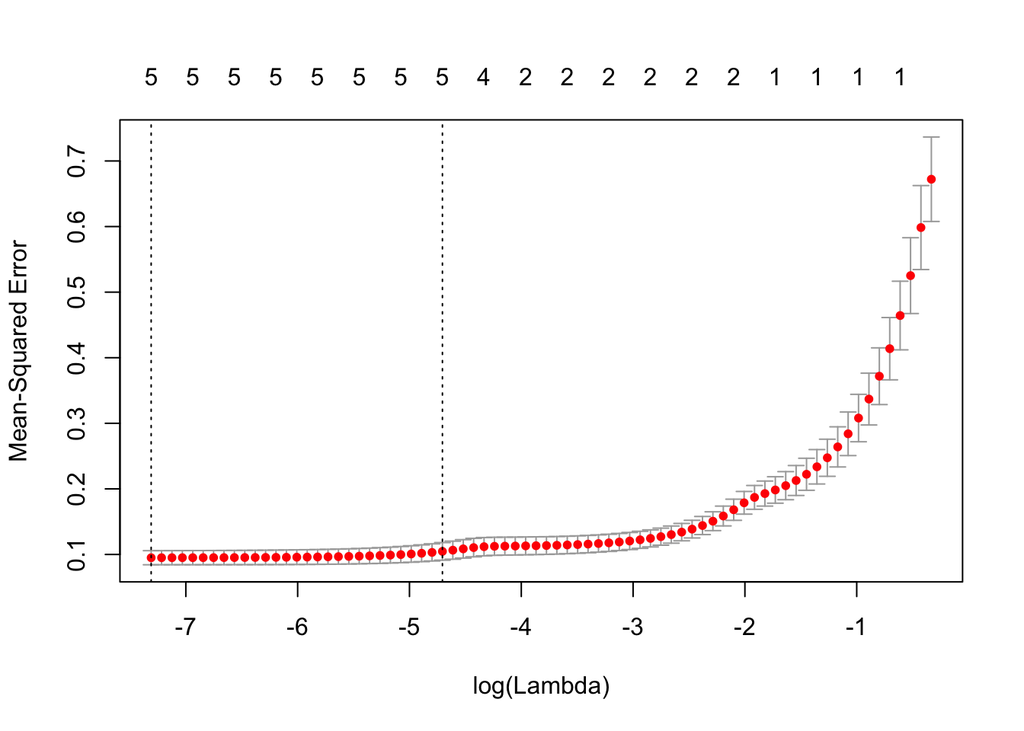

```r
library(glmnet) #For the cv.glmnet function
X <- scale(model.matrix(Sepal.Length ~ . -1, iris))
y <- iris$Sepal.Length - mean(iris$Sepal.Length)
fit <- cv.glmnet(X, y, standardize=FALSE, intercept = FALSE)
plot(fit) #Get an estimate for the optimal lambda
```

```r
# We will use the largest lambda value that is within one standard deviation of the lambda that gives the minimum MSE
lambda <- fit$lambda.1se
b <- fit$glmnet.fit$beta[,fit$lambda == lambda]
b
```

```
##       Sepal.Width      Petal.Length       Petal.Width     Speciessetosa
##        0.23573670        1.03342444       -0.09390900        0.09750230
## Speciesversicolor  Speciesvirginica
##        0.00000000       -0.05469309
```

```r
break_kkt(b, X, y, lambda)
```

```
## [1] FALSE FALSE FALSE FALSE FALSE FALSE
```

Since we calculated `b` using coordinate descent in the `cv.glmnet` function, we would expect the KKT Conditions would be fulfilled for every coefficient, and this is the case.

Now we change one of the values and see if that breaks the KKT Conditions.

```r
b_updated <- b
b_updated["Petal.Length"] <- 0 #This was originally non-zero
break_kkt(b_updated, X, y, lambda)
```

```
## [1] TRUE TRUE TRUE TRUE TRUE TRUE
```

```r
b_updated2 <- b
b_updated2["Speciesversicolor"] <- 0.01 #This was originally zero
break_kkt(b_updated2, X, y, lambda)
```

```
## [1]  TRUE FALSE FALSE  TRUE  TRUE  TRUE
```